# European Value Study - Survey Response Report

Attitudes towards gender roles and immigration

Jake Martin

March 30, 2024

# Country: Austria

## Description

This report summarizes the results of two survey questions concerning attitudes toward immigrants and women with children. The data was collected as part of the European Values Study, which is a “large-scale, cross-national and longitudinal survey research program on how Europeans think about family, work, religion, politics, and society.”

This report focuses on two questions that were asked in the survey:

*For each of the following statements I read out, can you tell me how strongly you agree or disagree with each.*

*When a mother works for pay, the children suffer*

*When jobs are scarce, employers should give priority to [nationality of respondent] people over immigrants*

*Do you strongly agree, agree, disagree, or strongly disagree?*

This report is based on responses from 1644 individuals age 18 or older.

For each survey question, “strongly agree” and “agree” responses have been grouped as a binary variable. In some cases, respondents with missing data have been excluded from analysis (e.g. respondents with missing age information are not included in analysis that discusses age).

## Tables

Table 1 summarizes the relationship between education and the percent of respondents who agree that *“When a mother works for pay, the children suffer.”*

Table 1: Percent agree: Gender roles by Education

| Education | Mean | Weighted n |
| --- | --- | --- |
| higher | 0.34 | 455 |
| lower | 0.65 | 312 |
| medium | 0.51 | 829 |
| other | 0.67 | 8 |

Table 2 summarizes the relationship between age (grouped into four categories) and the percent of respondents who agree that *“When jobs are scarce, employers should give priority to [nationality of respondent] people over immigrants”*

Table 2: Percent agree: Immigration views by Age

| Age group | Mean | Weighted n |
| --- | --- | --- |
| 18-34 | 0.43 | 368 |
| 35-49 | 0.47 | 376 |
| 50-64 | 0.54 | 435 |
| 65+ | 0.69 | 445 |

## Graphs

Figure 1 displays the relationship with age and the percent of respondents who agree that *“When a mother works for pay, the children suffer.”*

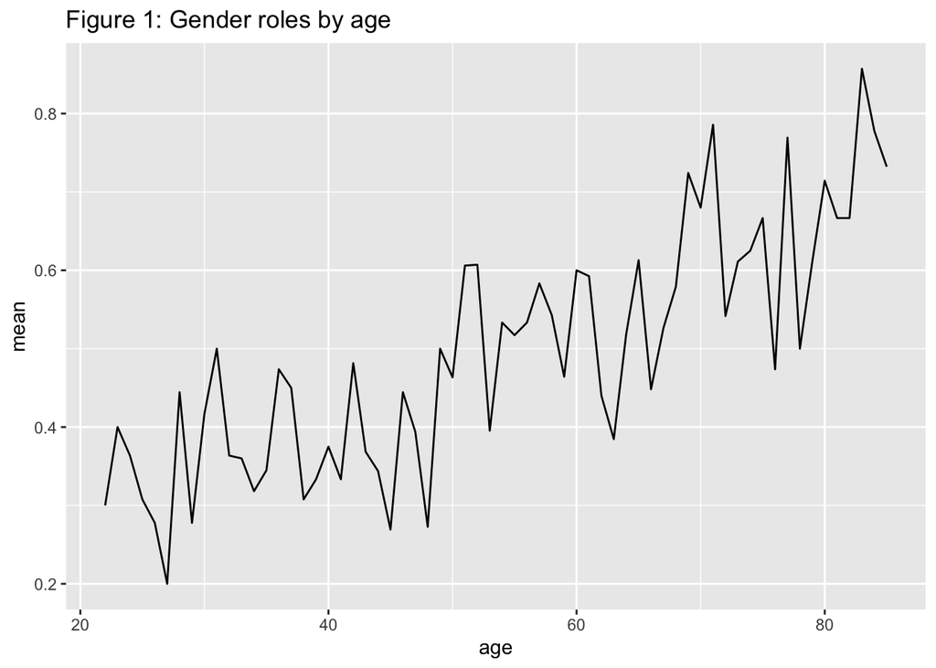

Figure 2 displays the relationship with age and the percent of respondents who agree that *“When jobs are scarce, employers should give priority to [nationality of respondent] people over immigrants.”*

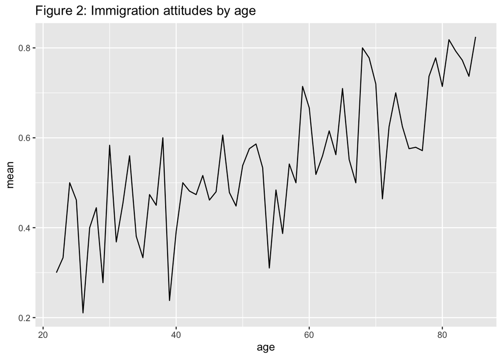

## Regressions

Table 3 illustrates a regression model explaining the relationship between gender roles (Model 1) and immigration (Model 2) by age, age squared, sex, and education.

Table 3: Regression model to explain the relationship between views on gender roles and immigration by select demographics

|  | Model 1 | Model 2 |
| --- | --- | --- |
| Intercept | 0.13 | 0.36** |
|  | (0.12) | (0.12) |
| Age | 0.01 | 0.00 |
|  | (0.00) | (0.00) |
| Age squared | 0.00 | 0.00 |
|  | (0.00) | (0.00) |
| Sex: male | 0.10*** | 0.03 |
|  | (0.02) | (0.02) |
| Education: lower | 0.10* | -0.00 |
|  | (0.04) | (0.04) |
| Education: higher | -0.17*** | -0.17*** |
|  | (0.03) | (0.03) |
| R<sup>2</sup> | 0.09 | 0.07 |
| Adj. R<sup>2</sup> | 0.08 | 0.06 |
| Num. obs. | 1598 | 1615 |

***p < 0.001; **p < 0.01; *p < 0.05

The regression model examining gender roles (Model 1) indicates indicates that there is a statistically significant positive relationship between men and agreement (Estimate = 0.1, p-value = 0) that “when a mother works for pay, the children suffer.”

The regression model examining immigration attitudes (Model 2) indicates that there is not a statistically significant negative relationship between lower education and agreement (Estimate = 0, p-value = 0.91) that “When jobs are scarce, employers should give priority to [nationality of respondent] people over immigrants.”